# Stat 4770/7770 Final Presentation

## Correlation Between Rurality Alone and Poor Health

##### The plot below provides a regression plot displaying the relationship between rurality and poor health outcomes across all counties.

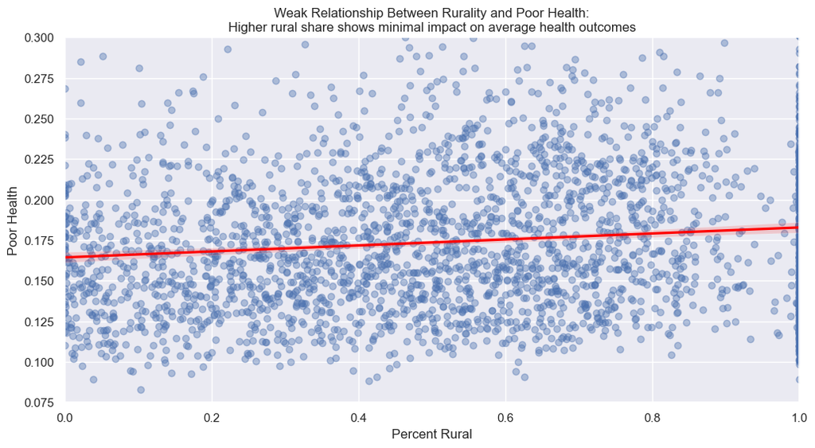

```python
plt.figure(figsize=(12,6))

ax = sns.regplot(data=county_data, x='Percent.Rural', y='Poor.Health',scatter_kws={'alpha':0.4}, line_kws={'color':'red'})

ax.set_title('Weak Relationship Between Rurality and Poor Health:\nHigher rural share shows minimal impact on average health outcomes')
ax.set_xlabel('Percent Rural')
ax.set_ylabel('Poor Health')
ax.set_xlim(0,1)
ax.set_ylim(0.075,0.30)

plt.show()
```

The weak slope of the regression line illustrates a low predictive power of rurality alone for poor health outcomes.

The bar chart below compares health outcomes across quartiles of rurality, where 0 represents fully urban counties on a spectrum to fully rural counties (1).

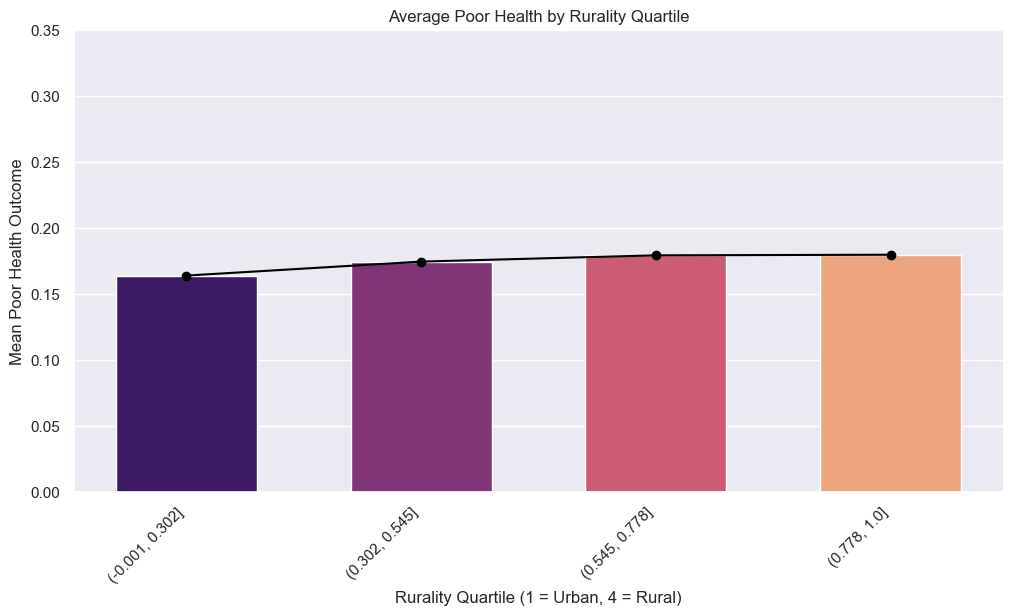

```python
rural_v_urban = county_data.groupby(pd.qcut(county_data['Percent.Rural'], 4))['Poor.Health'].mean().reset_index()
rural_v_urban.columns = ['Rurality Quartile', 'Mean Poor Health Outcome']

plt.figure(figsize=(12, 6))
ax = sns.barplot(data=rural_v_urban, x='Rurality Quartile', y='Mean Poor Health Outcome', width=0.6, palette='magma')
ax.set_xticklabels(ax.get_xticklabels(), rotation=45, ha='right')
ax.set_ylim(0, 0.35)
plt.title('Average Poor Health by Rurality Quartile')
plt.xlabel('Rurality Quartile (1 = Urban, 4 = Rural)')
plt.ylabel('Mean Poor Health Outcome')

ax.plot(range(len(rural_v_urban)), rural_v_urban['Mean Poor Health Outcome'], color='black', marker='o', linestyle='-', linewidth=1.5)
plt.show()
```

The relative similarity between bar height reinforces the weak relationship noted in the regression plot, displaying only modest differences in health outcomes between the least and most % rural counties.

## Regression Summary + Residual Analysis

The statistical summary of the regression plotted above indicates limited explanatory power with a R² of just 0.015.

A further analysis of the residual plot checks for any pattern in regression variance by checking that the weak relationship observed is not concealling non-linear and heteroscedastic trends. The Lowess line remains near to 0 across all values, confirming our finding that rurality has little to no systematic effect on poor health.

```
                            OLS Regression Results
==============================================================================
Dep. Variable:            Poor.Health   R-squared:                       0.015
Model:                            OLS   Adj. R-squared:                  0.015
Method:                 Least Squares   F-statistic:                     42.60
Date:                Fri, 24 Oct 2025   Prob (F-statistic):           8.00e-11
Time:                        23:59:13   Log-Likelihood:                 4578.1
No. Observations:                2715   AIC:                            -9152.
Df Residuals:                    2713   BIC:                            -9140.
Df Model:                           1
Covariance Type:            nonrobust
=================================================================================
                    coef    std err          t      P>|t|      [0.025      0.975]
---------------------------------------------------------------------------------
const             0.1644      0.002     93.386      0.000       0.161       0.168
Percent.Rural     0.0184      0.003      6.527      0.000       0.013       0.024
==============================================================================
Omnibus:                      282.026   Durbin-Watson:                   1.045
Prob(Omnibus):                  0.000   Jarque-Bera (JB):              407.293
Skew:                           0.791   Prob(JB):                     3.61e-89
Kurtosis:                       4.047   Cond. No.                         4.33
==============================================================================

Notes:
[1] Standard Errors assume that the covariance matrix of the errors is correctly specified.
```

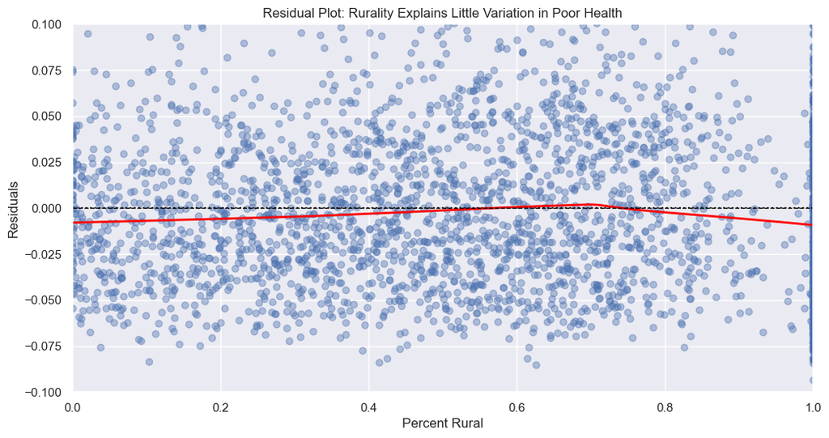

```python
import statsmodels.api as sm

X1 = sm.add_constant(county_data['Percent.Rural'])
y = county_data['Poor.Health']
olsmod1 = sm.OLS(y,X1).fit()
print(olsmod1.summary())

plt.figure(figsize=(12,6))

ax = sns.residplot(data=county_data, x='Percent.Rural', y='Poor.Health', lowess=True, scatter_kws={'alpha':0.4}, line_kws={'color':'red', 'lw':2})

ax.set_title('Residual Plot: Rurality Explains Little Variation in Poor Health')
ax.set_xlabel('Percent Rural')
ax.set_ylabel('Residuals')
ax.axhline(0, color='black', linestyle='--', linewidth=1)
ax.set_xlim(0, 1)
ax.set_ylim(-0.10, 0.10)

plt.show()
```

## Individual Predictor Variable Regression

From here, we next plot a regression for each of the choice structural variables with likely correlation to Poor Health outcomes. Assessing rurality in the context of these controls allows us to begin to understand the true underlying relationship between our outcome variable and rurality. *I've included our early plot of rurality itself for use in comparison.

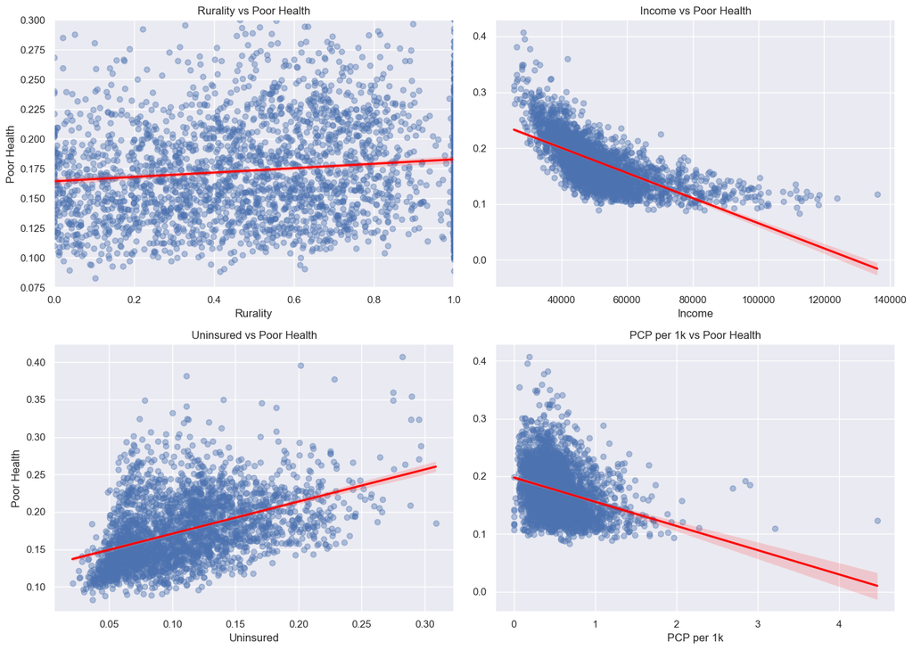

```python
fig, axes = plt.subplots(2, 2, figsize=(14, 10))
axes = axes.ravel()

sns.regplot(data=county_data, x='Percent.Rural', y='Poor.Health',
            scatter_kws={'alpha':0.4}, line_kws={'color':'red'}, ax=axes[0])
axes[0].set_title('Rurality vs Poor Health')
axes[0].set_xlabel('Rurality')
axes[0].set_ylabel('Poor Health')
axes[0].set_xlim(0, 1)
axes[0].set_ylim(0.075, 0.30)

sns.regplot(data=county_data, x='Median.Household.Income', y='Poor.Health',
            scatter_kws={'alpha':0.4}, line_kws={'color':'red'}, ax=axes[1])
axes[1].set_title('Income vs Poor Health')
axes[1].set_xlabel('Income')
axes[1].set_ylabel('')

sns.regplot(data=county_data, x='Uninsured', y='Poor.Health',
            scatter_kws={'alpha':0.4}, line_kws={'color':'red'}, ax=axes[2])
axes[2].set_title('Uninsured vs Poor Health')
axes[2].set_xlabel('Uninsured')
axes[2].set_ylabel('Poor Health')

sns.regplot(data=county_data, x='Primary.Care.Physicians.Per.1000', y='Poor.Health',
            scatter_kws={'alpha':0.4}, line_kws={'color':'red'}, ax=axes[3])
axes[3].set_title('PCP per 1k vs Poor Health')
axes[3].set_xlabel('PCP per 1k')
axes[3].set_ylabel('')

plt.tight_layout()
plt.show()
```

1. Our earlier plot of rurality; no notes
2. Income: A clear strong negative relationship suggesting income as a substanstial predictor variable for poor health outcomes.
3. Uninsured: Strong positive relationship, suggesting the more uninsured individuals within a county, the higher rate of poor health. An outcome of an outcome in a sense, a self-feeding loop contributing to poor health outcomes.
4. Primary Care Physican per 1000: Another strong negative relationship. Alongside insurance (access), suggests healthcare availability plays a large role in preventing poor health outcomes, INDEPDENT of rurality.

## OLS Regression Summary with Controls

Layering the above predictor variables into our earlier OLS regression of rurality increases R^2 to 0.553, a vastly stronger relationship.

```python
y = county_data['Poor.Health']

X2 = county_data[['Percent.Rural', 'Median.Household.Income', 'Uninsured', 'Primary.Care.Physicians.Per.1000']].copy()
X2.columns = ['Rurality', 'Income', 'Uninsured', 'PCP_per_1k']
X2 = sm.add_constant(X2)

model2 = sm.OLS(y, X2).fit()
print(model2.summary())
```

```
                            OLS Regression Results
==============================================================================
Dep. Variable:            Poor.Health   R-squared:                       0.553
Model:                            OLS   Adj. R-squared:                  0.553
Method:                 Least Squares   F-statistic:                     839.0
Date:                Sat, 25 Oct 2025   Prob (F-statistic):               0.00
Time:                        00:18:10   Log-Likelihood:                 5650.8
No. Observations:                2715   AIC:                        -1.129e+04
Df Residuals:                    2710   BIC:                        -1.126e+04
Df Model:                           4
Covariance Type:            nonrobust
==============================================================================
                 coef    std err          t      P>|t|      [0.025      0.975]
------------------------------------------------------------------------------
const          0.2932      0.004     70.923      0.000       0.285       0.301
Rurality      -0.0336      0.002    -15.160      0.000      -0.038      -0.029
Income     -2.158e-06      5e-08    -43.131      0.000   -2.26e-06   -2.06e-06
Uninsured      0.1987      0.013     15.057      0.000       0.173       0.225
PCP_per_1k    -0.0190      0.002     -9.556      0.000      -0.023      -0.015
==============================================================================
Omnibus:                      344.630   Durbin-Watson:                   1.163
Prob(Omnibus):                  0.000   Jarque-Bera (JB):              570.395
Skew:                           0.862   Prob(JB):                    1.38e-124
Kurtosis:                       4.439   Cond. No.                     1.24e+06
==============================================================================

Notes:
[1] Standard Errors assume that the covariance matrix of the errors is correctly specified.
[2] The condition number is large, 1.24e+06. This might indicate that there are
strong multicollinearity or other numerical problems.
```

Also note the F-statistic - 839.0 for a p < 0.0001 - confirms overall model significance between the joint predictor variables and Poor Health.

Even more of interest: among the coefficients, **RURALITY NOW HAS A NEGATIVE AND STATISTICALLY SIGNIFICANT (p < 0.001), REVERSING THE SIMPLE BIVARIATE SIGN** From this, we can assertain that once structural variables such as income, insurance coverage and PCP accesss are held constant, the more rural counties display slighty **better** health outcomes.

From here, we assess behavioral deterimants on the same basis:

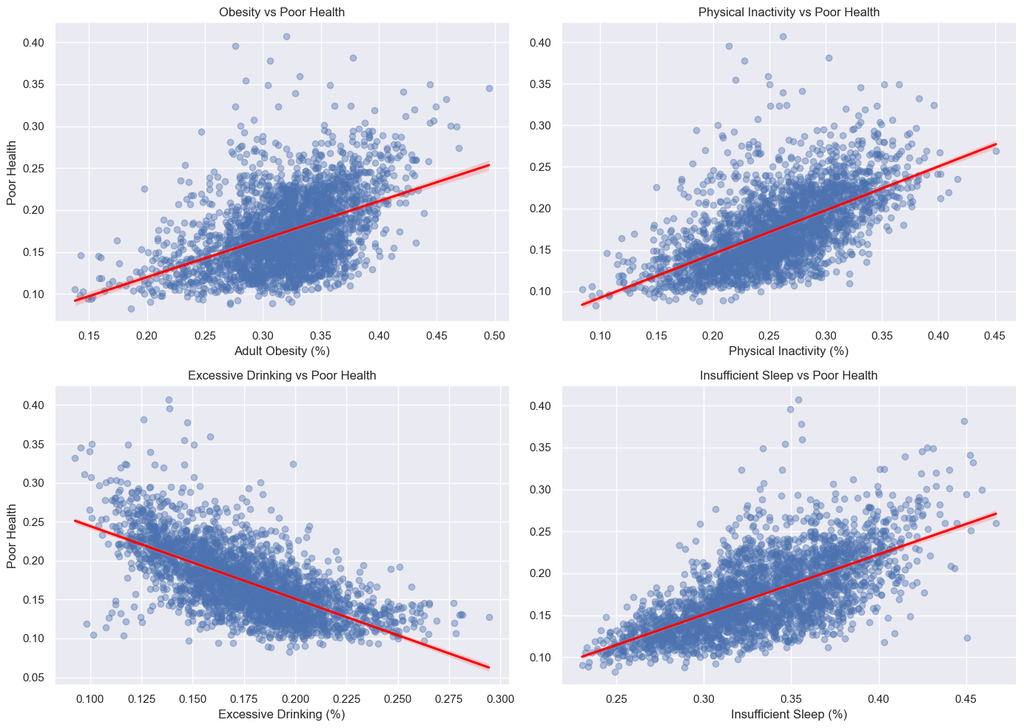

```python
y = county_data['Poor.Health']

X_behavioral = county_data[['Adult.Obesity', 'Physical.Inactivity', 'Excessive.Drinking', 'Insufficient.Sleep']].copy()
X_behavioral.columns = ['Obesity', 'Inactivity', 'Drinking', 'Sleep']

fig, axes = plt.subplots(2, 2, figsize=(14, 10))
axes = axes.ravel()

sns.regplot(data=county_data, x='Adult.Obesity', y='Poor.Health',
            scatter_kws={'alpha':0.4}, line_kws={'color':'red'}, ax=axes[0])
axes[0].set_title('Obesity vs Poor Health')
axes[0].set_xlabel('Adult Obesity (%)')
axes[0].set_ylabel('Poor Health')

sns.regplot(data=county_data, x='Physical.Inactivity', y='Poor.Health',
            scatter_kws={'alpha':0.4}, line_kws={'color':'red'}, ax=axes[1])
axes[1].set_title('Physical Inactivity vs Poor Health')
axes[1].set_xlabel('Physical Inactivity (%)')
axes[1].set_ylabel('')

sns.regplot(data=county_data, x='Excessive.Drinking', y='Poor.Health',
            scatter_kws={'alpha':0.4}, line_kws={'color':'red'}, ax=axes[2])
axes[2].set_title('Excessive Drinking vs Poor Health')
axes[2].set_xlabel('Excessive Drinking (%)')
axes[2].set_ylabel('Poor Health')

sns.regplot(data=county_data, x='Insufficient.Sleep', y='Poor.Health',
            scatter_kws={'alpha':0.4}, line_kws={'color':'red'}, ax=axes[3])
axes[3].set_title('Insufficient Sleep vs Poor Health')
axes[3].set_xlabel('Insufficient Sleep (%)')
axes[3].set_ylabel('')

plt.tight_layout()
plt.show()
```

Just as with the structural variables, each of the behavioral predictors display far more significant relationships with Poor Health. There is largely similarities between correlated behavioral determinants such as obesity and physical activity.

```python
X_behavioral = sm.add_constant(X_behavioral)
model_behavioral = sm.OLS(y, X_behavioral).fit()
print("Model: Behavioral Determinants")
print(model_behavioral.summary())
```

```
Model: Behavioral Determinants
                            OLS Regression Results
==============================================================================
Dep. Variable:            Poor.Health   R-squared:                       0.616
Model:                            OLS   Adj. R-squared:                  0.615
Method:                 Least Squares   F-statistic:                     1087.
Date:                Sat, 25 Oct 2025   Prob (F-statistic):               0.00
Time:                        00:51:46   Log-Likelihood:                 5856.0
No. Observations:                2715   AIC:                        -1.170e+04
Df Residuals:                    2710   BIC:                        -1.167e+04
Df Model:                           4
Covariance Type:            nonrobust
==============================================================================
                 coef    std err          t      P>|t|      [0.025      0.975]
------------------------------------------------------------------------------
const          0.0819      0.008     10.186      0.000       0.066       0.098
Obesity        0.0057      0.017      0.345      0.730      -0.027       0.038
Inactivity     0.1682      0.016     10.248      0.000       0.136       0.200
Drinking      -0.5300      0.021    -25.087      0.000      -0.571      -0.489
Sleep          0.4218      0.016     26.623      0.000       0.391       0.453
==============================================================================
Omnibus:                      819.169   Durbin-Watson:                   1.284
Prob(Omnibus):                  0.000   Jarque-Bera (JB):             4049.053
Skew:                           1.356   Prob(JB):                         0.00
Kurtosis:                       8.333   Cond. No.                         51.7
==============================================================================

Notes:
[1] Standard Errors assume that the covariance matrix of the errors is correctly specified.
```

Below I display the respective R^2 outputs in a bar graph for relative comparison. Note the sheer scale of difference between rurality alone and these compounded predictor variable models.

[figure not shown]

```python
r2_values = [0.015, 0.553, 0.619]
models = ['1. Rurality Only', '2. + Income & Access', '3. + Behavioral']

plt.figure(figsize=(10,5))
ax = sns.barplot(x=models, y=r2_values, palette='magma')

for i, (r2, coeff) in enumerate(zip(r2_values, rural_coeff)):
    ax.text(i, r2 + 0.03, f"R² = {r2:.3f}\nRural Coeff: {coeff}",
            ha='center', va='bottom', fontsize=15)

ax.set_ylim(0, 0.8)
ax.set_title('Model Fit Progression (R² Growth Across Models)')
ax.set_ylabel('R² Value')
ax.set_xlabel('Model')
plt.show()
```

### We now plot a regression of rurality and the residuals of health outcomes given our above structural controls:

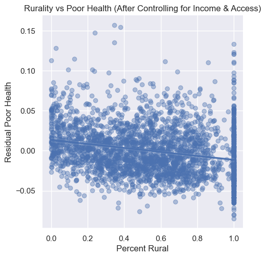

```python
X_controls = county_data[['Median.Household.Income', 'Uninsured', 'Primary.Care.Physicians.Per.1000']]
X_controls = sm.add_constant(X_controls)
y = county_data['Poor.Health']

control_model = sm.OLS(y, X_controls).fit()

county_data['health_resid'] = control_model.resid

sns.lmplot(
    data=county_data,
    x='Percent.Rural',
    y='health_resid',
    scatter_kws={'alpha':0.4}
)
plt.title('Rurality vs Poor Health (After Controlling for Income & Access)')
plt.ylabel('Residual Poor Health')
plt.xlabel('Percent Rural')

plt.show()
```

Findings: After controlling for structural deterimants, the residual plots assesses whether variation in poor health can be attributed to rurality. The weak and **even slightly negative** trend across % rural suggest that once these deteriments are accounted for, rurality itself has little effect, and can even be reversed to be attributed with better outcomes, to a minor degree.

### To confirm theses findings, we instead use Life Expectancy as our depedent variable, a far more simplistic measure of health outcomes:

**Important to note that life expectancy is a deeply imperfect tool of measurement for population health given it has shown far greater correltion with social and econoic conditions rather than the set of short-term health outcomes assessed with our earlier Poor Health variable.

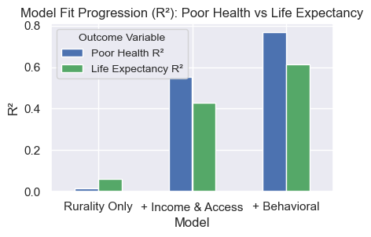

```python
y_health = county_data['Poor.Health']

X1 = sm.add_constant(county_data['Percent.Rural'])
model1 = sm.OLS(y_health, X1).fit()

X2 = county_data[['Percent.Rural', 'Median.Household.Income', 'Uninsured', 'Primary.Care.Physicians.Per.1000']]
X2 = sm.add_constant(X2)
model2 = sm.OLS(y_health, X2).fit()

X3 = county_data[['Percent.Rural', 'Median.Household.Income', 'Uninsured',
                  'Primary.Care.Physicians.Per.1000', 'Adult.Obesity',
                  'Physical.Inactivity', 'Excessive.Drinking', 'Insufficient.Sleep']]
X3 = sm.add_constant(X3)
model3 = sm.OLS(y_health, X3).fit()


y_life = county_data['Life.Expectancy']

X1 = sm.add_constant(county_data['Percent.Rural'])
model1_life = sm.OLS(y_life, X1).fit()

X2 = county_data[['Percent.Rural', 'Median.Household.Income', 'Uninsured', 'Primary.Care.Physicians.Per.1000']]
X2 = sm.add_constant(X2)
model2_life = sm.OLS(y_life, X2).fit()

X3 = county_data[['Percent.Rural', 'Median.Household.Income', 'Uninsured',
                  'Primary.Care.Physicians.Per.1000', 'Adult.Obesity',
                  'Physical.Inactivity', 'Excessive.Drinking', 'Insufficient.Sleep']]
X3 = sm.add_constant(X3)
model3_life = sm.OLS(y_life, X3).fit()

data = {
    'Model': ['Rurality Only', '+ Income & Access', '+ Behavioral'],
    'Poor Health R²': [model1.rsquared, model2.rsquared, model3.rsquared],
    'Life Expectancy R²': [model1_life.rsquared, model2_life.rsquared, model3_life.rsquared]
}
df_r2 = pd.DataFrame(data)

plt.figure(figsize=(12,6))
df_r2.plot(x='Model', y=['Poor Health R²', 'Life Expectancy R²'],
           kind='bar', color=['#4C72B0','#55A868'])

plt.title('Model Fit Progression (R²): Poor Health vs Life Expectancy')
plt.ylabel('R²')
plt.xticks(rotation=0)
plt.legend(title='Outcome Variable', title_fontsize = 10, fontsize = 10)
plt.tight_layout()
plt.show()
```

Rerunning the model with life expectancy instead confirms the same pattern we resolved on earlier. Rurality alone continues to explain vary little varation, and even in the context of the weaker Life Expectancy outcome variable, shows that rurality is dominated by structural and behavioral factors once layered on.

### Decision Tree:

To best understand the individual and compounded effect of numerous nonlinear relationships between health outcomes and predictors, we make usage of a decision tree model.

Each split in the data is based on thresholds unique to each predictor variable, reflecting differential weighting of different factors based on their influence on our ultimate outcome variable.

From this, we can ascern which of the variables hold the strongest influences, and understanidn how these effects compound into the county data we receive on Poor Health

```
R^2 (test): 0.6826220767765012
```

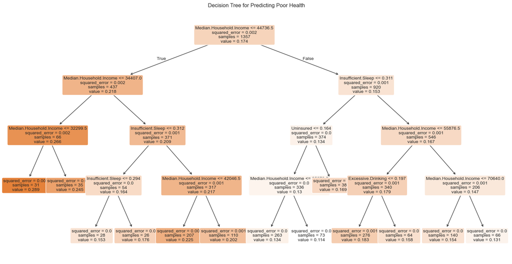

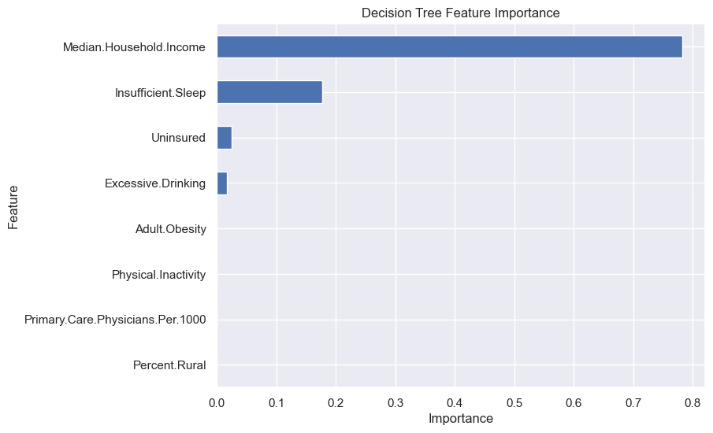

```python
from sklearn.tree import DecisionTreeRegressor, plot_tree
from sklearn.model_selection import train_test_split
from sklearn.metrics import r2_score

features = [
    'Percent.Rural', 'Median.Household.Income', 'Uninsured',
    'Primary.Care.Physicians.Per.1000', 'Adult.Obesity',
    'Physical.Inactivity', 'Excessive.Drinking', 'Insufficient.Sleep'
]
X = county_data[features]
y = county_data['Poor.Health']

X_train, X_test, y_train, y_test = train_test_split(
    X, y, test_size=0.5, random_state=42
)

tree = DecisionTreeRegressor(max_depth=4, min_samples_leaf=25, random_state=42)
tree.fit(X_train, y_train)

y_pred = tree.predict(X_test)
print("R^2 (test):", r2_score(y_test, y_pred))

plt.figure(figsize=(20,10))
plot_tree(tree, feature_names=features, filled=True, fontsize=10, rounded=True)
plt.title('Decision Tree for Predicting Poor Health')
plt.show()

importances = pd.Series(tree.feature_importances_, index=features).sort_values()
plt.figure(figsize=(8,6))
importances.plot(kind='barh')
plt.title('Decision Tree Feature Importance')
plt.xlabel('Importance')
plt.ylabel('Feature')
plt.show()
```